# Статистический анализ Индивидуальное домашнее задание №3 Вариант 8

Киреев Константин

23.12.2020

#### Результаты статистического эксперимента приведены в таблице 1. Требуется оценить характер (случайной) зависимости переменной Y от переменной X.

##### Таблица 1. $\alpha_1 = 0.05; h = 1.70$

```
##   [,1]  [,2] [,3]  [,4] [,5] [,6] [,7] [,8] [,9] [,10] [,11] [,12] [,13] [,14]
## x 3.00  2.00 1.00  2.00  0.0 2.00 3.00 1.00 1.00  2.00  3.00   3.0  3.00  3.00
## y 8.89 10.33 8.22 12.15  6.6 7.65 8.64 4.05 6.68  2.27 10.63   5.7  8.92  4.59
##   [,15] [,16] [,17] [,18] [,19] [,20] [,21] [,22] [,23] [,24] [,25] [,26] [,27]
## x  2.00  0.00  3.00  1.00  1.00  2.00  2.00  3.00  2.00  1.00  1.00  4.00  2.00
## y 10.82 11.09  2.14  6.63  8.02  6.99  8.28  7.01  4.09  8.52  5.48  9.92  7.35
##   [,28] [,29] [,30] [,31] [,32] [,33] [,34] [,35] [,36] [,37] [,38] [,39] [,40]
## x  2.00  2.00  1.00   1.0  1.00  1.00  3.00  2.00  2.00  3.00  4.00  4.00  3.00
## y  9.92 10.16 10.49   9.1  7.29  5.29  5.06  8.32  7.64 10.25  9.02  8.92  4.98
##   [,41] [,42] [,43] [,44] [,45] [,46] [,47] [,48] [,49] [,50]
## x  3.00  4.00  3.00  2.00  2.00  3.00  2.00  3.00  1.00  2.00
## y  8.33  6.61  9.19 11.52  9.74  6.55  5.67  6.01  4.57  2.29
```

#### *Задание 1*

##### Построить графически результаты эксперимента. Сформулировать линейную регрессионную модель переменной Y по переменной X. Построить МНК оценки параметров сдвига $\beta_0$ и масштаба $\beta_1$. Построить полученную линию регрессии. Оценить визуально соответствие полученных данных и построенной оценки.

$$\begin{align}
& Y_i = \beta_0+\beta_1X_i + \varepsilon_i, \varepsilon_i - N(0, \sigma^2) \\
& \beta_1 = \frac{\bar{xy}-\bar{x}\bar{y}}{\bar{x^2}-\bar{x}^2} = 0.0621511 \\
& \beta_0 = \bar{Y} - \beta_1\bar{X} = 7.4385966 \\
& Y = \hat{\beta_1}X + \beta_0 = 0.0621511X + 7.4385966
\end{align}$$

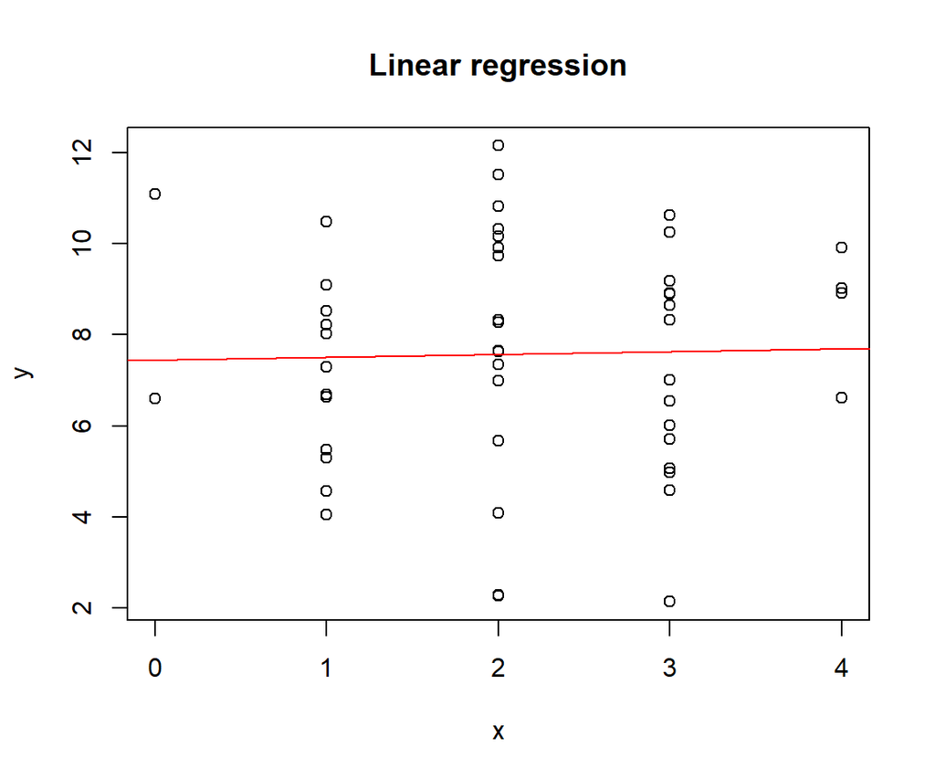

#### *Задание 2*

##### Построить и интерпретировать несмещенную оценку дисперсии. На базе ошибок построить гистограмму с шагом $h$. Проверить гипотезу нормальности ошибок на уровне $\alpha_1$ по $\chi^2$. Оценить расстояние полученной оценки до класса нормальных распределений по Колмогорову. Визуально оценить данный факт.

$$\begin{align}
\hat{\sigma}^2=\frac{1}{n-2}&\sum\limits_{1}^{n}(Y-\bar{Y})^2 = 6.1827473 \\
\varepsilon_i=&Y_i -\hat{\beta_1}X_i - \hat{\beta_0}
\end{align}$$

###### $\varepsilon_1, ..., \varepsilon_n:$

```
##  [1]  1.26495002  2.76710116  0.71925230  4.58710116 -0.83859656  0.08710116
##  [7]  1.01495002 -3.45074770 -0.82074770 -5.29289884  3.00495002 -1.92504998
## [13]  1.29495002 -3.03504998  3.25710116  3.65140344 -5.48504998 -0.87074770
## [19]  0.51925230 -0.57289884  0.71710116 -0.61504998 -3.47289884  1.01925230
## [25] -2.02074770  2.23279888 -0.21289884  2.35710116  2.59710116  2.98925230
## [31]  1.59925230 -0.21074770 -2.21074770 -2.56504998  0.75710116  0.07710116
## [37]  2.62495002  1.33279888  1.23279888 -2.64504998  0.70495002 -1.07720112
## [43]  1.56495002  3.95710116  2.17710116 -1.07504998 -1.89289884 -1.61504998
## [49] -2.93074770 -5.27289884
```

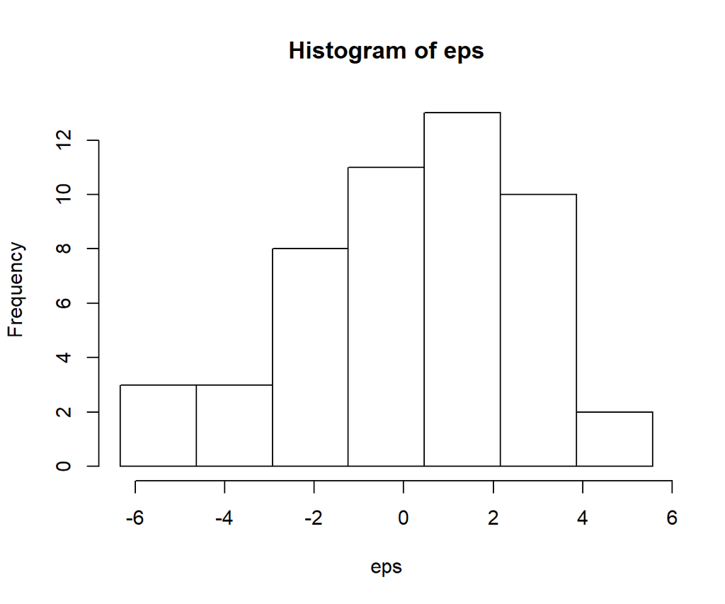

$$\begin{align}
& H_0:\varepsilon_1, ..., \varepsilon_n \sim N(0, \sigma^2) \\
& \sum\limits_{i=1}^{r}\frac{n_i-np_i(0, \sigma^2))^2}{np_i(0, \sigma^2)} \rightarrow \chi^2_{кр}
\end{align}$$

Метод минимизации хи-квадрат

$$\begin{equation}
\underset{\sigma^2}{argmin}\sum\limits_{i=1}^{r}\frac{n_i-np_i(0, \sigma^2))^2}{np_i(0, \sigma^2)}
\end{equation}$$

##### Разделим выборку на 6 зон:

| Интервал | $(-\infty; -3.4)$ | $(-3.4; -1.7)$ | $(-1.7; 0)$ | $(0; 1.7)$ | $(1.7; 3.4)$ | $(3.4; \infty)$ |
| --- | --- | --- | --- | --- | --- | --- |
| $m_i$ | 5 | 8 | 10 | 15 | 9 | 3 |

##### Задача реализована в R с помощью скрипта:

```r
csq <- function(sgm.sq){
  prob <- pnorm(up, 0, sgm.sq) - pnorm(lw, 0, sgm.sq)
  return (sum((m-n*prob)^2)/prob/n)
}
XM <- nlm(csq, sqrt(s))
XM$estimate^2; XM$minimum
```

##### Получаем $\hat{\sigma}^2=6.0184705$ и $\chi^2_{набл}=1.5922697$

$$\begin{align}
l&=r - d - 1 = 4 \\
\chi^2_{кр} &=9.487729 \\
\chi^2_{набл}=1.5922697 < \chi^2_{кр} & = 9.487729 \Rightarrow \text{гипотеза $H_0$ принимается}
\end{align}$$

##### Оценим расстояние оценки до класса нормальных распределений по Колмогорову. Минимизируем статистику Колмогорова с помощью следующего скрипта:

```r
kolm.stat<-function(s){
  sres<-sort(eps)
  fdistr<-pnorm(sres,0,s)
  max(abs(c(0:(n-1))/n-fdistr),abs(c(1:n)/n-fdistr))
}
ks.dist<-nlm(kolm.stat, 2.453257)
```

##### Получаем расстояние $D = 0.0756747$ и $\tilde{\sigma}^2 = 8.4739449$. Ниже представлены эмпирическая функция распределения ошибок и фукнция распределения $N(0, \tilde{\sigma}^2)$.

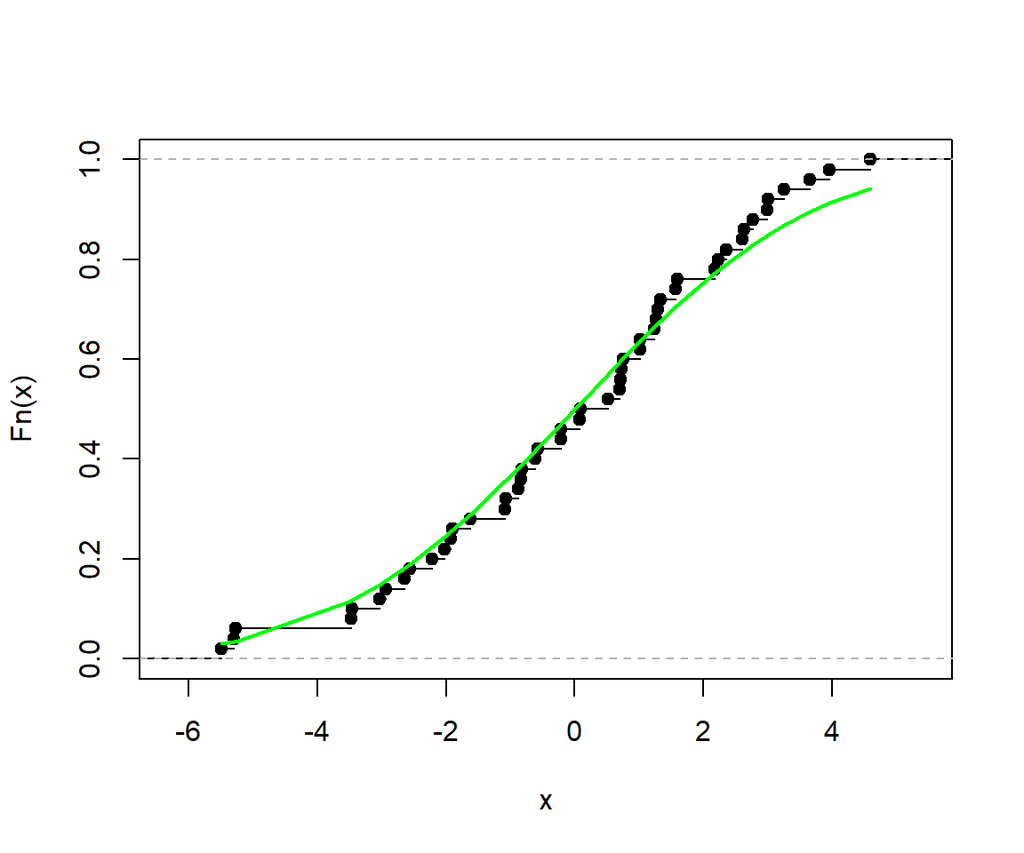

#### *Задание 3*

##### В предположении нормальности ошибок построить доверительные интервалы для параметров $\beta_0$ и $\beta_1$ уровня доверия $1-\alpha_1$. Построить доверительный эллипс уровня доверия $1-\alpha_1$ для $(\beta_0, \beta_1)$ (вычислить его полуоси).

$$\begin{align}
\psi&=C^T\beta \\
\hat{\psi}\sim N(\psi, \sigma^2b), \sigma^2b&=var(\hat{\psi})=\sigma^2C^T(XX^T)^{-1}C \\
\frac{\hat{\psi}-\psi}{\sigma\sqrt{b}}\sim N(0, 1);&\frac{(n-r)s^2}{\sigma^2}\sim \chi^2_{n-r}\Rightarrow \frac{\hat{\psi}-\psi}{s\sqrt{b}}\sim S_{n-r} \\
x_{\alpha}:&S_{n-r}(x_{\alpha})=1-\frac{\alpha}{2} \\
P(-x_{\alpha} \leqslant \frac{\hat{\psi}-\psi}{s\sqrt{b}} \leqslant &x_{\alpha})=P(\hat{\psi}-x_{\alpha}s\sqrt{b} \leqslant \psi \leqslant \hat{\psi}+x_{\alpha}s\sqrt{b}) \\
x_{\alpha}&=2.0106348 \\
\beta_0 \in (5.7687784; &9.1084148) \text{ - ДИ с уровнем доверия }1-\alpha \\
\beta_1 \in (-0.6447393; &0.7690416) \text{ - ДИ с уровнем доверия }1-\alpha
\end{align}$$

$$\begin{align}
&\frac{(\hat{\psi}-\psi)^T(C^T(XX^T)^{-1}C)^{-1}(\hat{\psi}-\psi)}{\sigma^2}\sim\chi^2_q \\
&\frac{((\hat{\psi}-\psi)^T(C^T(XX^T)^{-1}C)^{-1}(\hat{\psi}-\psi)q\sigma^2)}{\frac{n-r}{n+r}\cdot\frac{s^2}{\sigma^2}}=\frac{(\hat{\psi}-\psi)^T(C^T(XX^T)^{-1}C)^{-1}(\hat{\psi}-\psi)}{qs^2}\sim F_{q, n-r}
\end{align}$$
$$\begin{align}
& x_{\alpha}: F_{q, n-r}(x_{\alpha})=1-\alpha \\
& \left\{ \psi: (\hat{\psi}-\psi)^T(C^T(XX^T)^{-1}C)^{-1}(\hat{\psi}-\psi) \leqslant s^2qx_{\alpha} \right\} \\
& x_{\alpha} = 3.1907273 \\
& \begin{pmatrix} \beta_1-\hat{\beta_1} & \beta_0-\hat{\beta_0} \end{pmatrix} \begin{pmatrix} 0.019992 & -0.0427829 \\ -0.0427829 & 0.1115554 \end{pmatrix} \begin{pmatrix} \beta_1-\hat{\beta_1} \\ \beta_0-\hat{\beta_0} \end{pmatrix} \leqslant 39.4549219
\end{align}$$

Собственные числа матрицы: **0.1284342, 0.0031132**  
После ортогонального преобразования получаем:

$$\begin{align}
0.1284342(\beta_1^*-0.0621511)^2&+0.0031132(\beta_0^*+7.4385966)^2 \leqslant 39.4549219 \\
\frac{(\beta_1^*-0.0621511)^2}{17.5271082^2}&+\frac{(\beta_0^*+7.4385966)^2}{112.5765063^2} \leqslant 1
\end{align}$$

Полуоси эллипса: **17.5271082; 112.5765063**.

#### *Задание 4*

##### Сформулировать гипотезу независимости переменной Y от переменной X. Провести проверку значимости.

$$\begin{align}
& \psi=C^T\beta; \hat{\psi}\sim N(\psi, \sigma^2C^T(XX^T)^{-1}C) \\
& H_0: \psi=0 \\
& \text{Статистика F-критерия:} \\
& F=\frac{\hat{\psi^T(C^T(XX^T)^{-1}C)^{-1}\hat{\psi}}}{qs^2}\overset{H_0}{\sim}F_{q, n-r} \\
& F=0.0312507 \\
& x_{\alpha}: F_{q, n-r}(x_{\alpha})=1-\alpha; \phi(Y, X)=1_{F>x_{\alpha}} \\
& x_{\alpha}=4.0426521 \\
& H_1: \hat{\psi}=\beta_1
\end{align}$$
$$\begin{align}
& F<x_{\alpha}\Rightarrow \text{ Принимаем гипотезу $H_0$, переменная 𝑌 независима с переменной 𝑋 на уровне значимости 𝛼}\\
& 0.8604259 \text{ – наибольшее значение уровня значимости, на котором нет оснований отвергнуть данную гипотезу.}
\end{align}$$

#### *Задание 5*

##### Сформулировать модель, включающую дополнительный член с $X^2$. Построить МНК оценки параметров $\beta_1, \beta_2, \beta_3$ в данной модели. Изобразить графически полученную регрессионную зависимость.

$$\begin{align}
& Y_i = \beta_3+\beta_2X_i+\beta_1X_i^2+\varepsilon_i, \varepsilon_i\sim N(0, \sigma^2) \\
& \hat{\beta}=(X^TX)^{-1}X^TY \\
& \hat{\beta}=\begin{pmatrix}\hat{\beta_1} \\ \hat{\beta_2} \\ \hat{\beta_3}\end{pmatrix}=\begin{pmatrix}0.190431 \\ -0.744725 \\ 8.1027066\end{pmatrix}
\end{align}$$

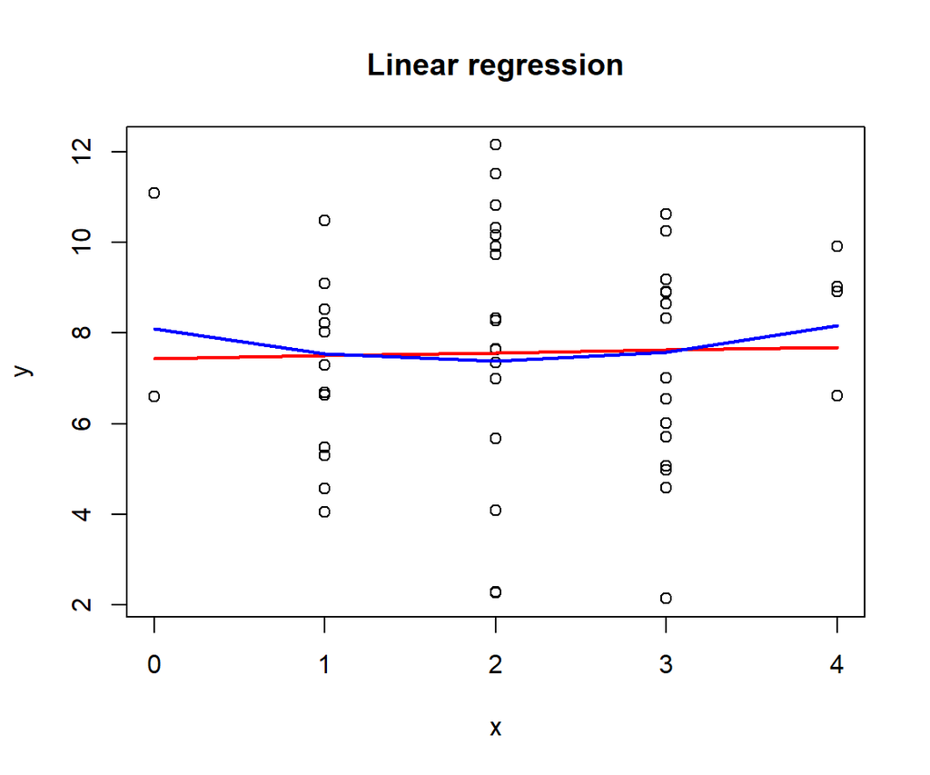

#### *Задание 6*

##### Построить несмещенную оценку дисперсии. Провести исследование нормальности ошибок как в п.3.

$$\begin{align}
\hat{\sigma}^2=\frac{1}{n-3}&\sum\limits_{1}^{n}(Y_i-\hat{\beta_1}X_i^2-\hat{\beta_2}X_i-\hat{\beta_3})^2 = 6.2575876 \\
& \varepsilon_i=\hat{Y}-X^T\hat{\beta}
\end{align}$$

###### $\varepsilon_1, ..., \varepsilon_n:$

```
##  [1]  1.30758951  2.95501947  0.67158744  4.77501947 -1.50270658  0.27501947
##  [7]  1.05758951 -3.49841256 -0.86841256 -5.10498053  3.04758951 -1.88241049
## [13]  1.33758951 -2.99241049  3.44501947  2.98729342 -5.44241049 -0.91841256
## [19]  0.47158744 -0.38498053  0.90501947 -0.57241049 -3.28498053  0.97158744
## [25] -2.06841256  1.74929755 -0.02498053  2.54501947  2.78501947  2.94158744
## [31]  1.55158744 -0.25841256 -2.25841256 -2.52241049  0.94501947  0.26501947
## [37]  2.66758951  0.84929755  0.74929755 -2.60241049  0.74758951 -1.56070245
## [43]  1.60758951  4.14501947  2.36501947 -1.03241049 -1.70498053 -1.57241049
## [49] -2.97841256 -5.08498053
```

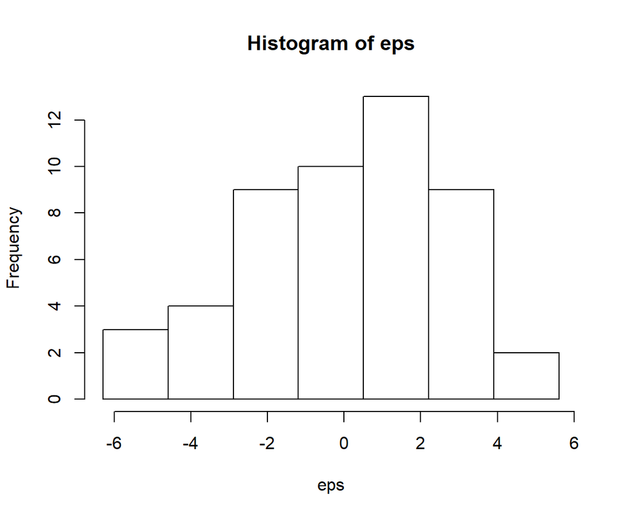

$$\begin{align}
& H_0:\varepsilon_1, ..., \varepsilon_n \sim N(0, \sigma^2) \\
& \sum\limits_{i=1}^{r}\frac{n_i-np_i(0, \sigma^2))^2}{np_i(0, \sigma^2)} \rightarrow \chi^2_{кр}
\end{align}$$

Метод минимизации хи-квадрат

$$\begin{equation}
\underset{\sigma^2}{argmin}\sum\limits_{i=1}^{r}\frac{n_i-np_i(0, \sigma^2))^2}{np_i(0, \sigma^2)}
\end{equation}$$

##### Разделим выборку на 6 зон:

| Интервал | $(-\infty; -3.4)$ | $(-3.4; -1.7)$ | $(-1.7; 0)$ | $(0; 1.7)$ | $(1.7; 3.4)$ | $(3.4; \infty)$ |
| --- | --- | --- | --- | --- | --- | --- |
| $m_i$ | 4 | 9 | 10 | 15 | 9 | 3 |

##### Получаем $\hat{\sigma}^2=5.5559278$ и $\chi^2_{набл}=1.4170828$

$$\begin{align}
l&=r - d - 1 = 4 \\
\chi^2_{кр} &=9.487729 \\
\chi^2_{набл}=1.4170828 < \chi^2_{кр} & = 9.487729 \Rightarrow \text{гипотеза $H_0$ принимается}
\end{align}$$

##### Оценим расстояние оценки до класса нормальных распределений по Колмогорову. Минимизируем статистику Колмогорова с помощью следующего скрипта:

```r
kolm.stat<-function(s){
  sres<-sort(eps)
  fdistr<-pnorm(sres,0,s)
  max(abs(c(0:(n-1))/n-fdistr),abs(c(1:n)/n-fdistr))
}
ks.dist<-nlm(kolm.stat, 2.357102)
```

##### Получаем расстояние $D = 0.0777714$ и $\tilde{\sigma}^2 = 7.8117778$. Ниже представлены эмпирическая функция распределения ошибок и фукнция распределения $N(0, \tilde{\sigma}^2)$.

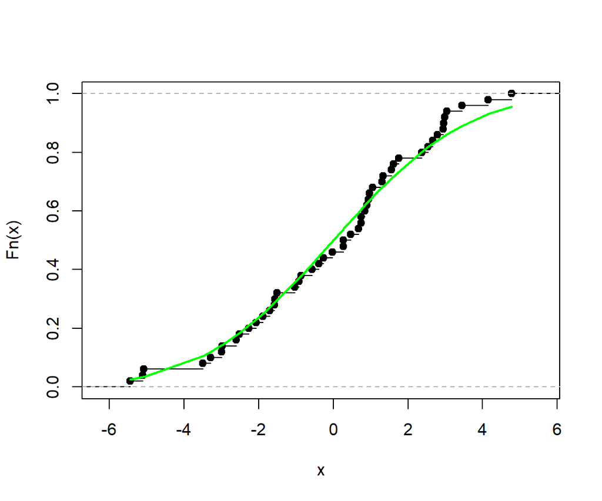

#### *Задание 7*

##### В предположении нормальности ошибок построить доверительные интервалы для параметров $\beta_1, \beta_2, \beta_3$ уровня $1-\alpha_1$. Написать уравнение доверительного эллипсоида уровня доверия $1-\alpha_1$.

$$\begin{align}
& \psi=C^T\beta; \hat{\psi}\sim N(\psi, \sigma^2C^T(XX^T)^{-1}C) \\
& x_{\alpha}: S_{n-r}(x_{\alpha})=1-\frac{\alpha}{2} \\
& P(\hat{\psi}-x_{\alpha}s\sqrt{b} \leqslant \psi \leqslant \hat{\psi}+x_{\alpha}s\sqrt{b}) \\
& x_{\alpha} = 2.0117405 \\
& \beta_1 \in (-0.4190854; 0.7999474) \text{ - ДИ с уровнем доверия }1-\alpha \\
& \beta_2 \in (-3.4235389; 1.9340889) \text{ - ДИ с уровнем доверия }1-\alpha \\
& \beta_3 \in (5.3928258; 10.8125874) \text{ - ДИ с уровнем доверия }1-\alpha
\end{align}$$

$$\begin{align}
& x_{\alpha}: F_{q, n-r}(x_{\alpha})=1-\alpha \\
& \left\{ \psi: (\hat{\psi}-\psi)^T(C^T(XX^T)^{-1}C)^{-1}(\hat{\psi}-\psi) \leqslant s^2qx_{\alpha} \right\} \\
& x_{\alpha} = 2.8023552
\end{align}$$
$$\begin{align}
& \begin{pmatrix} \beta_1-\hat{\beta_1} & \beta_2-\hat{\beta_2} & \beta_3-\hat{\beta_3} \end{pmatrix} \begin{pmatrix} 0.0146697 & -0.0621569& 0.051159 \\ -0.0621569 & 0.2833572 & -0.2595491 \\ 0.051159 & -0.2595491 & 0.2899676 \end{pmatrix} \begin{pmatrix} \beta_1-\hat{\beta_1} \\ \beta_2-\hat{\beta_2} \\ \beta_3-\hat{\beta_3} \end{pmatrix} \leqslant 52.607949
\end{align}$$

$$\begin{align}
0.5580359(\beta_1^*-0.190431)^2&+0.0296035(\beta_2^*-(-0.744725))^2+3.5505965\times 10^{-4}(\beta_3^*-8.1027066)^2 \leqslant 52.607949 \\
\frac{(\beta_1^*-0.190431)^2}{9.7094494^2}&+\frac{(\beta_2^*-(-0.744725))^2}{42.1555085^2}+\frac{(\beta_3^*-8.1027066)^2}{384.9240317^2} \leqslant 1
\end{align}$$

Полуоси эллипсоида: **9.7094494; 42.1555085; 384.9240317**.

#### *Задание 8*

##### Сформулировать гипотезу линейной регрессионной зависимости переменной Y от переменной X и проверить ее значимость на уровне $\alpha_1$.

$$\begin{align}
& \psi=C^T\beta; \hat{\psi}\sim N(\psi, \sigma^2C^T(XX^T)^{-1}C) \\
& H_0: \psi=0 \\
& \text{Статистика F-критерия:} \\
& F=\frac{\hat{\psi^T(C^T(XX^T)^{-1}C)^{-1}\hat{\psi}}}{qs^2}\overset{H_0}{\sim}F_{q, n-r} \\
& F=0.3950467 \\
& x_{\alpha}: F_{q, n-r}(x_{\alpha})=1-\alpha; \phi(Y, X)=1_{F>x_{\alpha}} \\
& x_{\alpha}=4.0470999 \\
& H_1: \hat{\psi}=\beta_1
\end{align}$$
$$\begin{align}
& F<x_{\alpha}\Rightarrow \text{ Принимаем гипотезу $H_0$, переменная 𝑌 линейно регрессионно зависима с переменной 𝑋 на уровне значимости 𝛼}\\
& 0.5327012 \text{ – наибольшее значение уровня значимости, на котором нет оснований отвергнуть данную гипотезу.}
\end{align}$$